# RelatorioFinal_ICD (1)

## **Introdução a Ciência de Dados**

## Projeto: *HDI and Suicide Rates*

**Alunos:**

1. Julia Manuela Guerreiro Soares - 2018048532
2. Rodrigo Barbosa Faria - 2018019036
3. Thiago Nunes Coelho Nascimento - 2018019044
4. Vinicius de Oliveira Marcos - 2019007090

## **Introdução**

O suicídio pode ser definido como um ato deliberado, realizado pelo indivíduo de forma consciente, cuja intenção seja a própria morte, mesmo que ambivalente, usando um meio que ele acredita ser letal. É um comportamento com múltiplos determinantes e resultado de uma complexa interação de fatores psicológicos e biológicos, inclusive genéticos, culturais e socioambientais.

É importante ressaltar que, devido ao preconceito e ao estigma que o suicídio carrega, os dados estatísticos sobre o suicídio são subnotificados, o que mascara uma realidade preocupante, pois estima-se que cerca de um milhão de pessoas morre anualmente, por suicídio, o que levou a OMS a considerar o suicídio como uma epidemia silenciosa. Trata-se de uma questão de saúde pública.

Fonte: https://unilab.edu.br/prevencao-do-suicidio/

Nosso objetivo, com este projeto, sabendo que o suícidio pode resultar de fatores culturais e socioambientais, é analisar as possíveis relações entre o *Indíce de Desenvolvimento Humano* de um país e suas taxas de suícidio e investigar este fenômeno.

## **Links importantes:**

**Vídeo de apresentação:** https://youtu.be/5qjkG1Uh2Fs

**Github:** https://github.com/JuliaGuerreiro/ProjetoFinalICD

## **Perguntas**

1. Qual a influência do IDH de um país no índice de suicídios?
2. Como a riqueza de um país se relaciona com sua taxa de suicídio?
3. Como o gênero e a idade das pessoas se relaciona com a taxa de suicídio de um país?
4. É possível prever a taxa de suicídio de um país com base em seu IDH ao longo dos anos?

## **Bases de Dados**

Para o desenvolvimento deste projeto, foram utilizadas apenas duas bases de dados - sendo uma delas a principal e outra auxiliar no processo de análise exploratória.

#### **Suicide Rates Overview 1985 to 2016**

Descrição: Esse conjunto de dados apresenta dados relativos aos níveis e números de suícidios por país, além de valores correspondentes a fatores socio-econômicos. Os dados retratam um período de 1985 a 2016.

Fonte: [Suicide Rates Overview 1985 to 2016](https://www.kaggle.com/russellyates88/suicide-rates-overview-1985-to-2016)

#### **Country Mapping - ISO, Continent, Region**

Descrição: Nesse conjunto de dados são apresentados todos os países, seus respectivos continentes e regiões - com o adicional de identificadores para cada um destes.

Fonte: [Country Mapping - ISO, Continent, Region](https://www.kaggle.com/andradaolteanu/country-mapping-iso-continent-region)

## **Tratamento de Dados**

Para simplificar a base utilizada neste projeto, o período analisado foi reduzido aos anos de 2010 a 2016. A coluna relativa à idade, que apresentava a idade por intervalos (ex.: 55-74 years) foi removida e em seu lugar foi considerada apenas a geração do conjunto de pessoas. Também, com o intuito de focar apenas em dados específicos, as colunas mantidas para estudo foram: país, ano, sexo, número de suícidios, taxa de suícidio a cada 100k pessoas, IDH, renda per capita e geração (relativa ao intervalo de tempo em que uma determinada pessoa nasceu).

## **Análise de Dados**

#### **Número de suícidios ao longo dos anos (período de 2010 a 2015)**

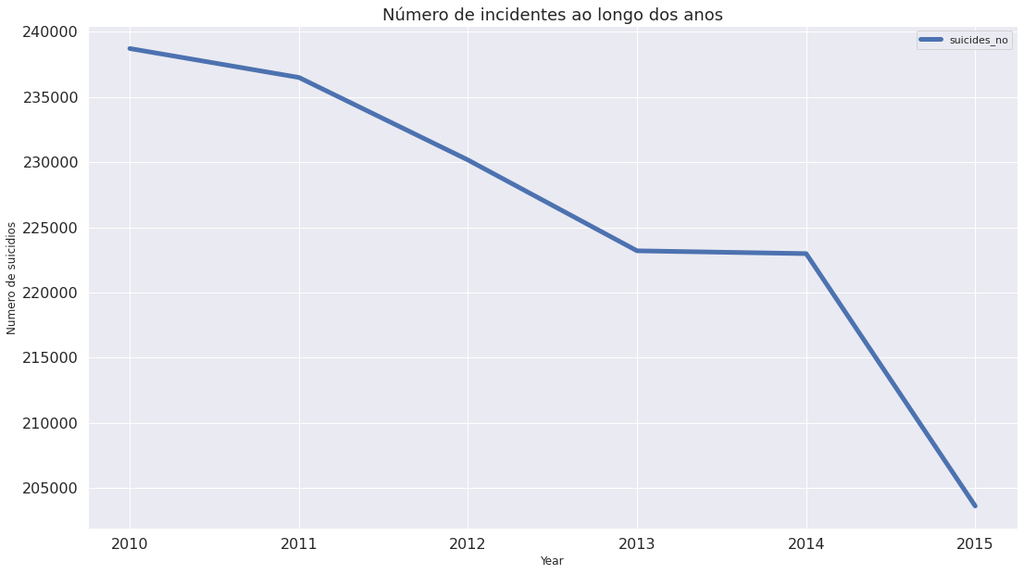

Aqui, podemos observar que o número de suícidios decresceu ao longo dos anos, no entanto, devido a escala utilizada, pode-se perceber que o decréscimo não foi tão alto.

#### **Média da taxa de suícidio ao longo dos anos (período de 2010 a 2015)**

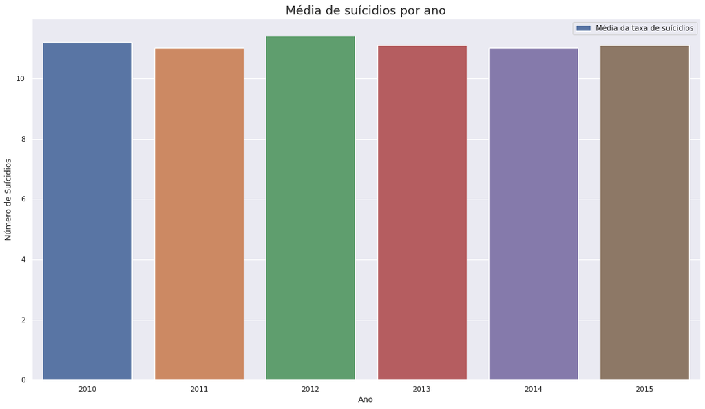

Durante esse período, é possível perceber que a média de casos se manteve estável e sem poucas variações.

#### **Número de suícidios por sexo ao longo dos anos (período de 2010 a 2015)**

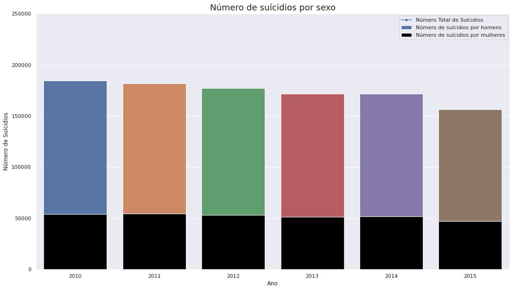

Aqui é possível perceber que o número de suicídios cometidos por homens é muito superior ao número de suicídios cometidos por mulheres. Esse foi um padrão observado em todos os anos analisados.

#### **Número de suícidios por geração ao longo dos anos (período de 2010 a 2015)**

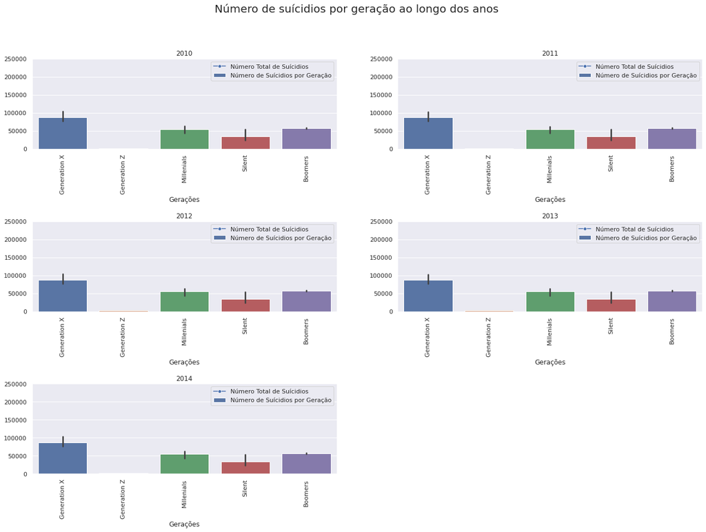

#### **Evolução de casos de suícidios ao longo dos anos (período de 2010 a 2015)**

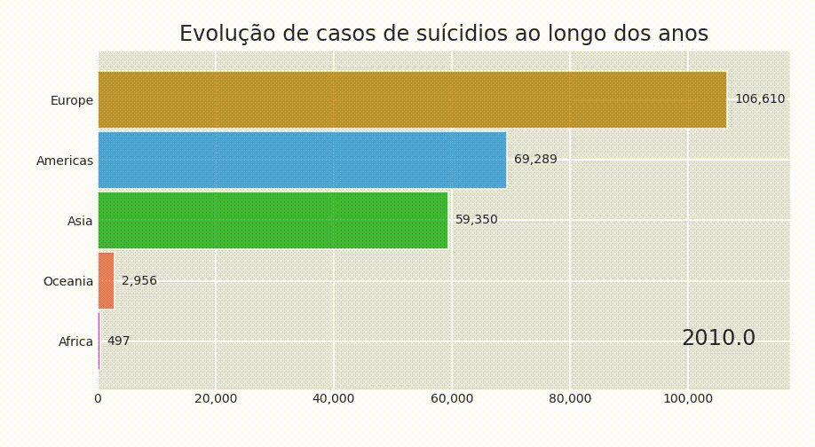

Aqui é possível observar que em sua grande maioria, os casos de suícidios ocorrem na Europa, Américas e Ásia. Dentre esses, pode-se observar um rápido crescimento nos números nas Américas e pouca variação nos números da Europa. Já na Ásia, os números apresentaram variações ao longo dos anos, mas o continente ainda se manteve com grandes números.

#### **Análise de HDI e GPD por país ao longo dos anos (período 2010 a 2015)**

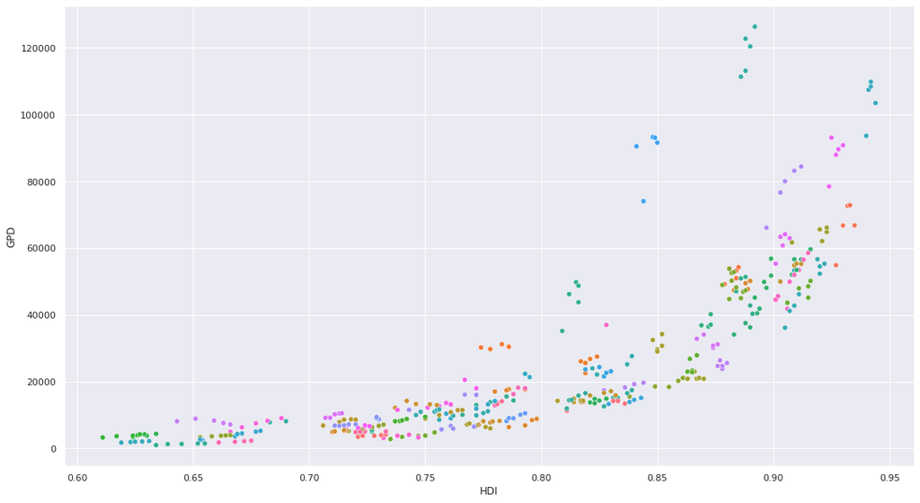

Aqui é possível observar que quanto maior o GDP maior o HDI. Outro ponto interessante é notar que não há muita variação nessas taxas entre os países, tendo em vista que os pontinhos de mesma cor permanecem sempre muito próximos.

#### **Análise dos 10 países com maiores taxas de suícidio e suas respectivas GPDs**

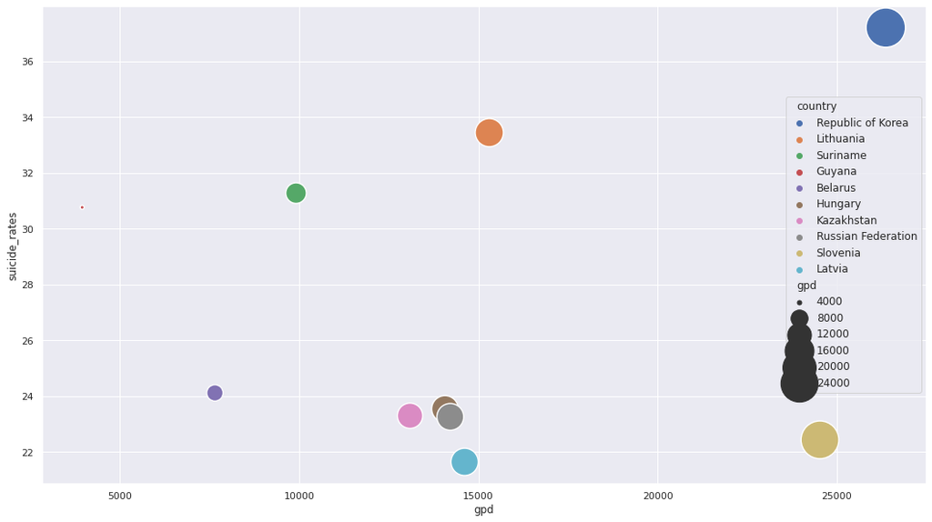

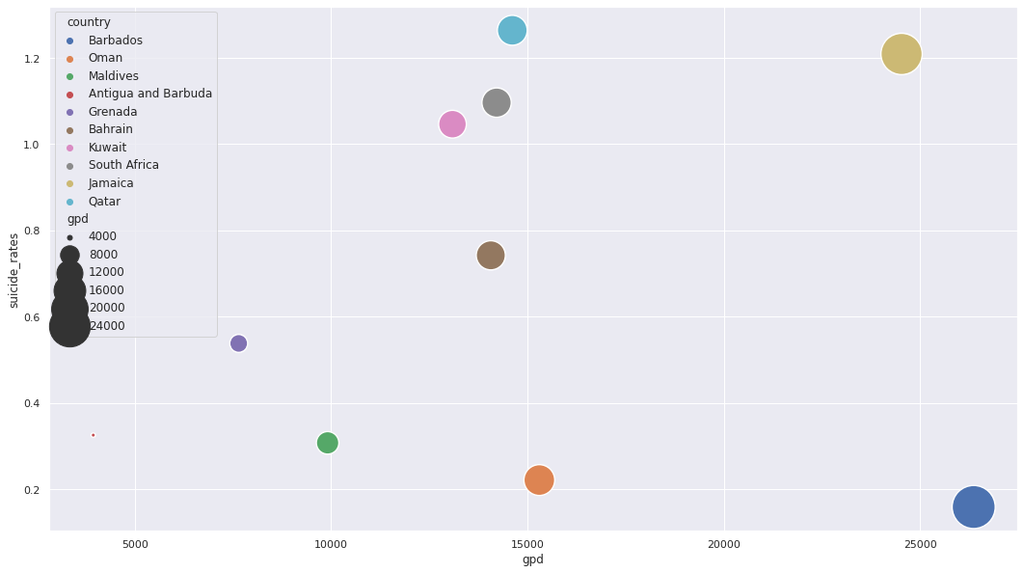

## **Testes de Hipótese & Intervalos de Confiança**

**Hipótese nula**: países com maior desenvolvimento possuem menor taxa de suicídios;

**Hipótese alternativa**: países com maior desenvolvimento possuem maiores taxas de suicídios.

Utilizando boostrap vamos verificar a chance de um país considerado mais desenvolvido ter maior taxa de suicidios que os paises menos desenvolvidos.

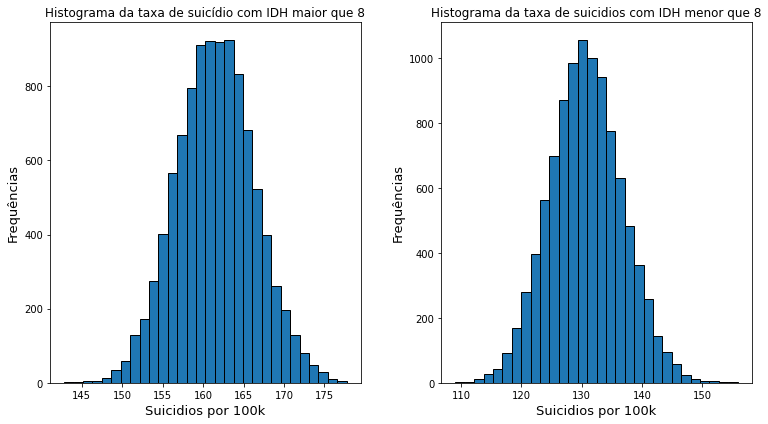

Aqui vemos que as distribuições acima não coincidem no gráfico.

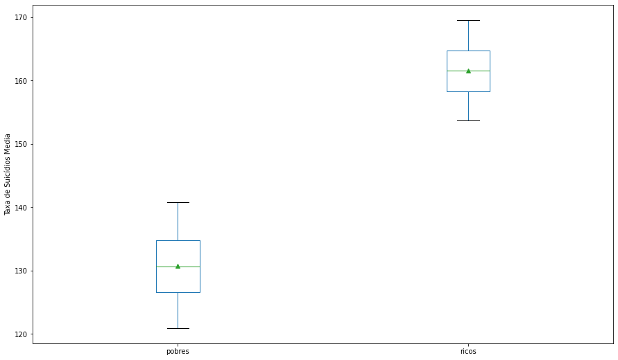

Abaixo temos o número de suicídios dos países com IDH maior do que 8 e dos menores do que 8.

[figure not shown]

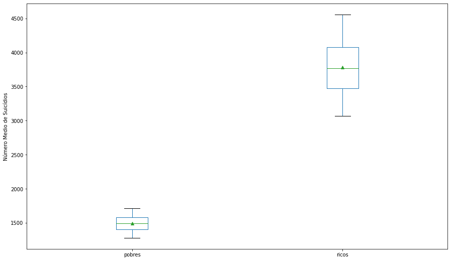

Os gráficos abaixo mostram as distribuições de renda per capita nos países com IDH maior do que 8 e menor do que 8. É possível verificar que a renda per capita nos países mais desenvolvidos é muito maior do que nos países em desenvolvimento.

[figure not shown]

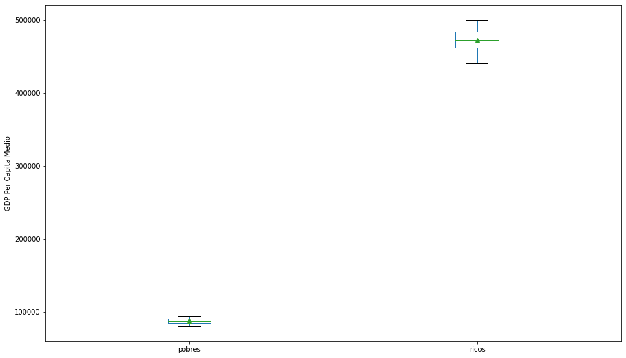

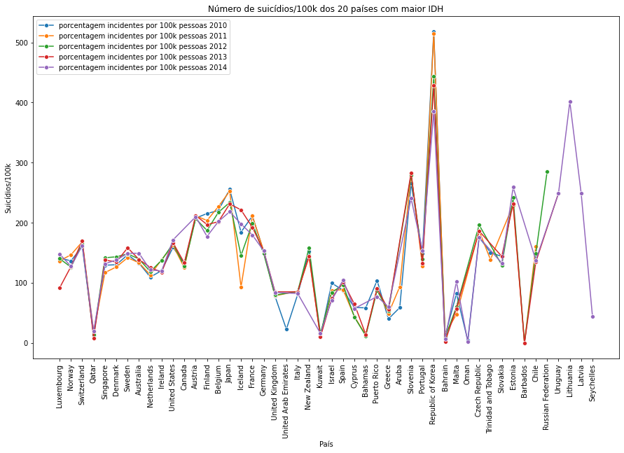

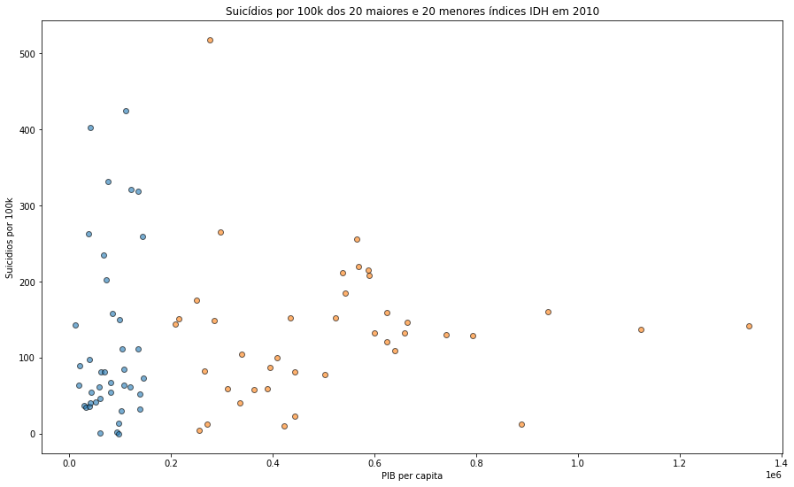

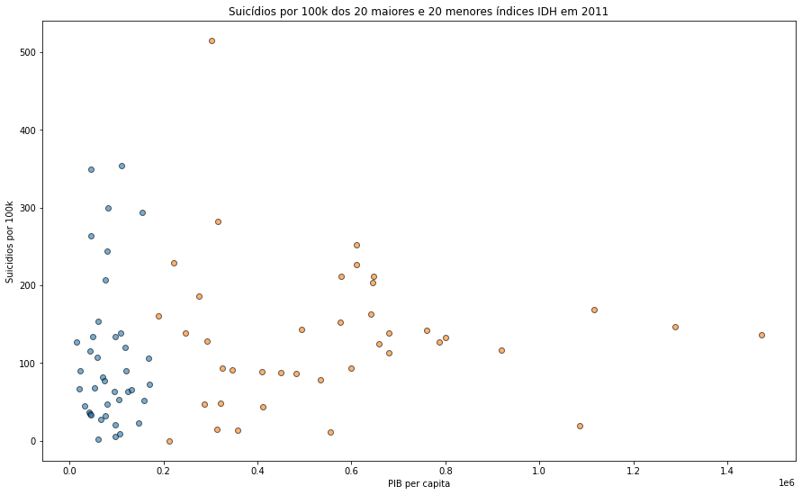

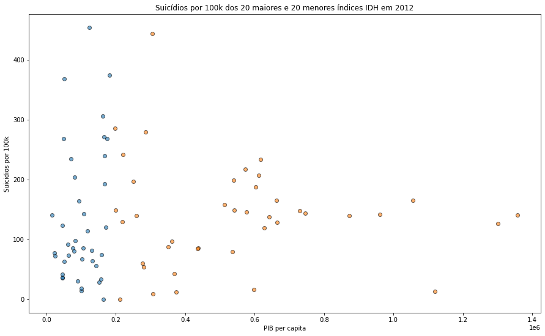

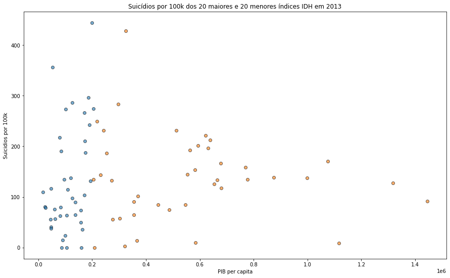

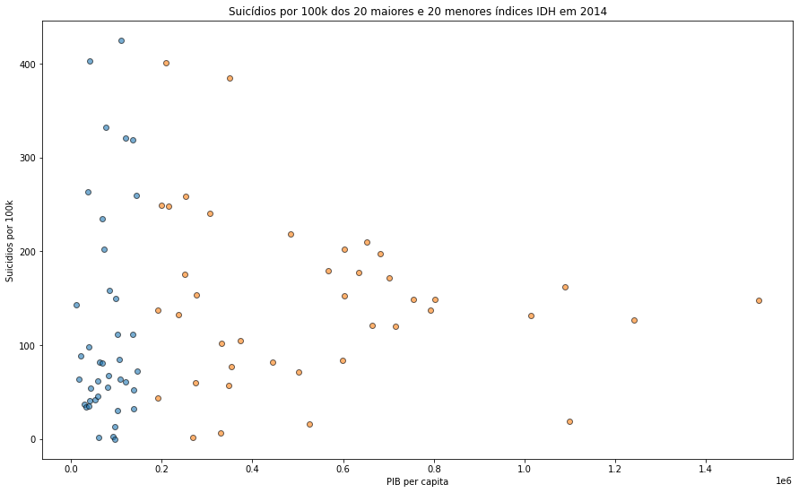

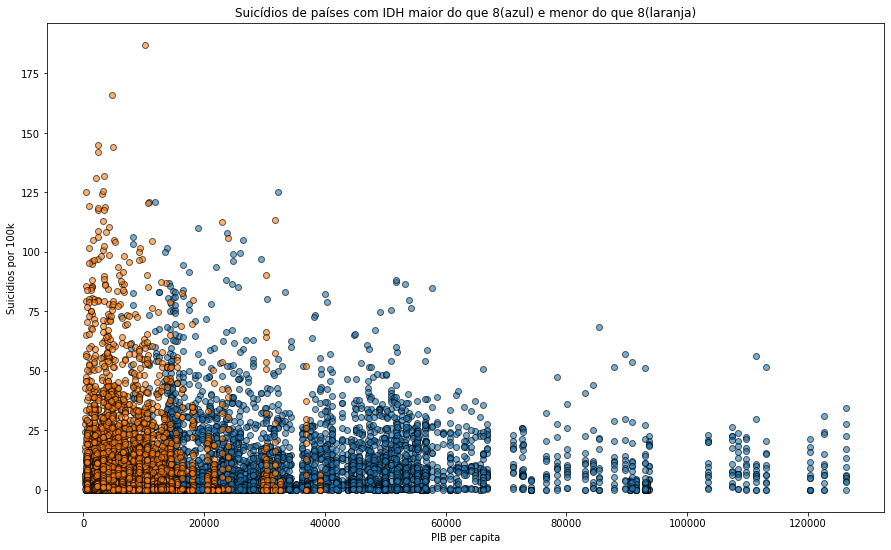

## **Regressão**

**Taxa de Suicídio em função do IDH (2010-2014)**

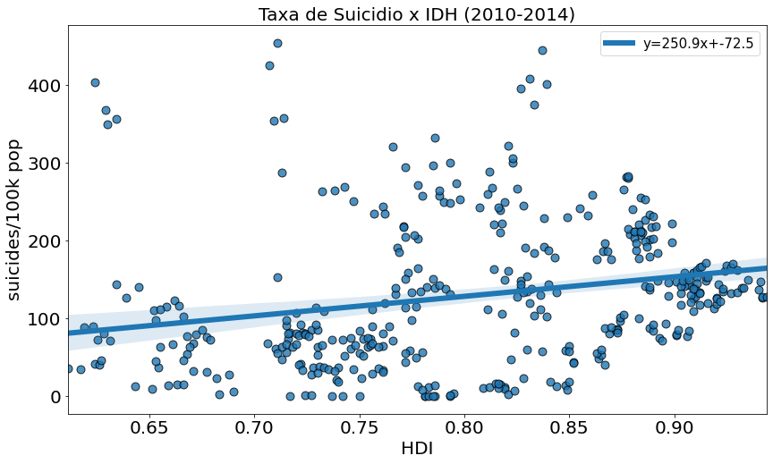

Com o coeficiente R-quadrado de 0,05, conclui-se que a regressão linear se ajusta pouco aos dados e a variação do IDH influencia pouco a variação da taxa de suicídio.

**Taxa de suicídio em função do IDH (ano a ano)**

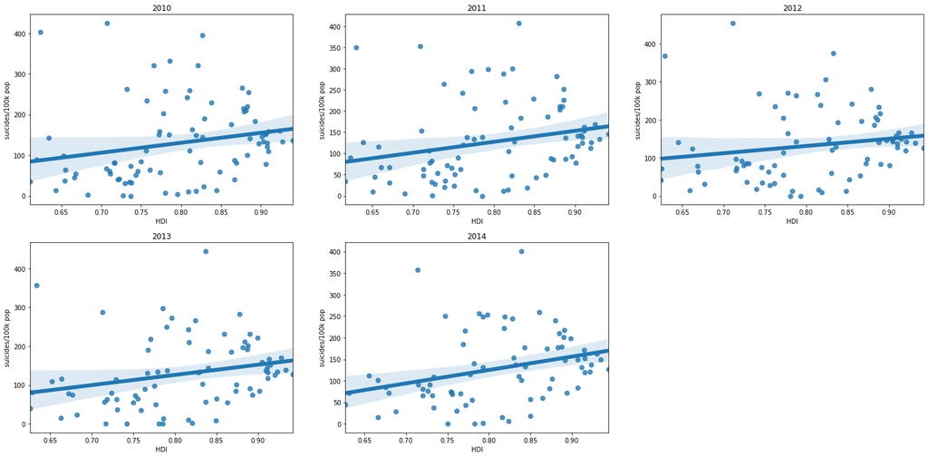

Acima, os gráficos mostram que a dispersão dos dados continua bem semelhante com o passar do tempo e que a taxa de suicídio tem um leve aumento quanto maior for o IDH.

**Regressão por KNN**

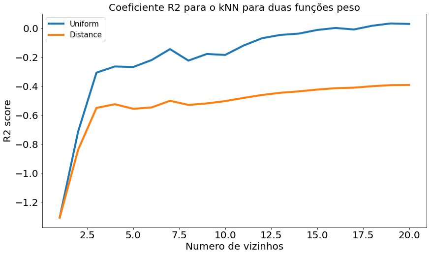

Para ambas funções de peso e variando o número de vizinhos do kNN, o coeficiente de determinação retornou valores bem baixos, especialmente para poucos vizinhos. Isso demonstra a dificuldade para se realizar a previsão da taxa de suicídio de um país tendo como base apenas o seu IDH, e outros algoritmos mais robustos de aprendizado de máquina necessitariam ser testados.

**Taxa de suicidio com base na renda per capita (GPD)**

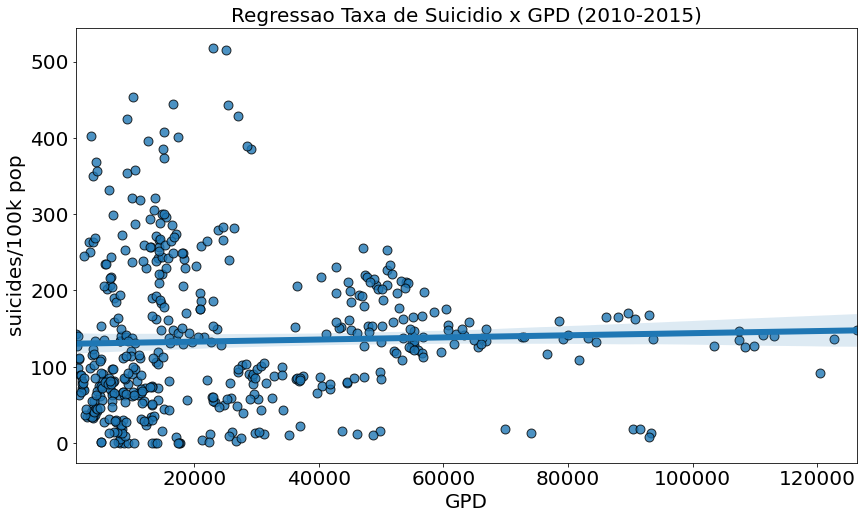

**Taxa de suicidio com base na renda per capita (Ano a ano)**

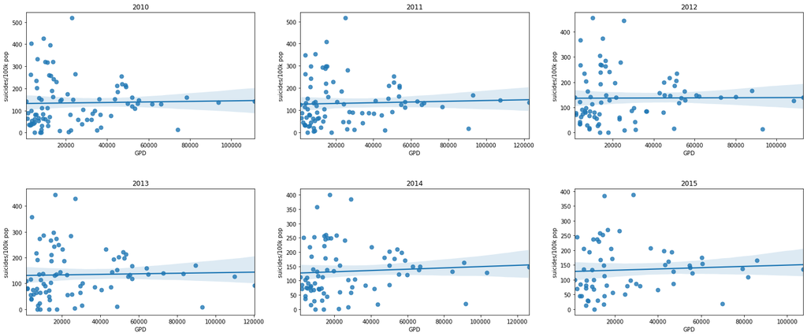

Os gráficos de regressão linear mostram a baixíssima correlação linear entre a renda per capita e a taxa de suicídio, seja em um ano específico ou durante todo o período.

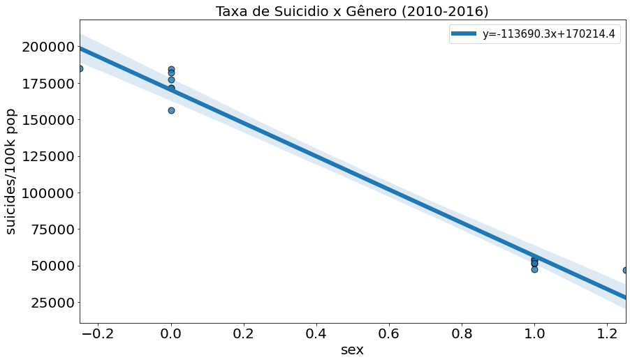

Com a regressão acima é possível observar que o gênero de uma boa possui uma influencia relevante no que diz respeito aos casos de suicídio. Ou seja, o padrão observado anteriormente - onde homens são mais suscetíveis a cometer suicídios - pode ser confirmado aqui.

(Nesse caso, homens são representados por 0 e mulheres por 1.)

## **Conclusão**

Tendo em vista as nossas perguntas iniciais, podemos concluir alguns pontos. Segundo a análise, ao longo dos anos é possível notar uma mínima variação nas taxas de suicídio quando são considerados o IDH e o GPD de um país. No que foi observado, pode-se dizer que há uma leve tendência em países onde o IDH é mais elevado, no entanto, não pode-se afirmar com exatidão devido aos números baixos retornados.

Um pouco a se ressaltar é aquele mencionado em nossa introdução: os casos de suicídio são normalmente influenciados por uma combinação de fatores e não apenas por um deles isoladamente, e isso pôde ser observado em nossa pesquisa. Isoladamente, os indicadores socio-econômicos foram insuficientes para se chegar a alguma conclusão ou mesmo prever padrões futuros.

Em relação à idade das pessoas, pôde-se observar uma maior têndencia entre as pessoas já adultas. Os casos em crianças e adolescentes foram quase irrelevantes.

Já em relação ao gênero, chegamos a uma conclusão interessante. Pôde-se perceber que os homens possuem uma maior tendência a concluir tal ato do que as mulheres e isso pôde ser observado através de uma rápida análise exploratória e em sua confirmação através de uma regressão. Acreditamos que essa foi uma descoberta interessante mas que também não deve ser considerada isoladamente, tendo em vista que há vários outros fatores que podem vir a influenciar mais fortemente os homens.

Em suma, nota-se que a análise de casos de suicídio é uma análise tão complexa quanto o tema e exige a investigação de vários fatores simultâneamente para que possamos chegar em resultados mais conclusivos e que possam gerar algum impacto positivo na sociedade e na saúde-pública.